# 2D Poisson Equation

```python
%pylab inline
import numpy as np
import matplotlib.pyplot as plt
from numpy import exp,sin,pi
from matplotlib import animation
from JSAnimation import IPython_display
```

# Numerics Basic

- $x\in[0,l]$: $x_0=0<x_1=\triangle x<x_2=2\triangle x<\cdots<x_i=i \triangle x<\cdots<x_n=l$, $=\triangle x=\frac{l}{n}$;
- $y\in[0,m]$: $y_0=0<y_1=\triangle y<y_2=2\triangle y<\cdots<y_i=i \triangle y<\cdots<y_n=l$, $=\triangle y=\frac{m}{n}$;
- discretization: $u(x_i,y_j)= U(i,j)$
- the simulated value $U_{i,j}$ of $u(x_i,y_j)$: $U_{i,j} =\frac{1}{2\triangle x^2+2\triangle y^2}\left( \triangle x^2(U_{i,j-1}+U_{i,j+1})+ \triangle y^2(U_{i-1,j}+U_{i+1,j}) -f(x_i,y_j)\triangle x^2\triangle y^2)\right)$

Now to plot your solution, you'll need to reshape $U$ to be the shape of the grid; i.e, $m\times m$. Then you can plot it using the function plt.pcolor().

```python
def num_update(u,f, dx2, dy2):
    u[1:-1,1:-1] = ( (u[2:,1:-1]+u[:-2,1:-1])*dy2 + (u[1:-1,2:] + u[1:-1,:-2])*dx2 -f[1:-1,1:-1] *dx2*dy2 )/2./(dx2+dy2)
    return u
BC= lambda x,y: 1
ff=  lambda x,y: 0
```

```python
def calc(ff,N, Niter=100,func=num_update, bc=BC):
    #order = 'C' if func not in [for_update1, for_update2] else 'F'
    #u = zeros([N, N], order=order)
    u = np.zeros([N+1, N+1])
    f = np.zeros([N+1, N+1])
    #u[0] = 1
    #u[0]=np.array(N,N,lambda i,j:u0(float(i/N),float(j/N)))
    h=1./float(N)
    dx = h
    dy = h
    dx2 = h*h
    dy2 = h*h
    xmesh=np.linspace(0,1,N+1)
    ymesh=np.linspace(0,1,N+1)
    for j in np.arange(N+1):
        u[j,0]=BC(xmesh[j],ymesh[0])
        u[0,j]=BC(xmesh[0],ymesh[j])
        u[j,-1]=BC(xmesh[j],ymesh[-1])
        u[-1,j]=BC(xmesh[-1],ymesh[j])
        for i in np.arange(N+1):
            f[i,j]=ff(xmesh[i],ymesh[j])
    #for i in np.arange(N+1):
    #    for j in np.arange(N+1):
    #        f[i,j]=ff(xmesh[i],ymesh[j])
    #print(f*dx2*dy2 /2./(dx2+dy2))
    for i in np.arange(Niter):
        u=func(u,f, dx2,dy2)
    return u
```

```python
def calcNP(ff,N, Niter=100,func=num_update, bc=BC):
    #order = 'C' if func not in [for_update1, for_update2] else 'F'
    #u = zeros([N, N], order=order)
    u = np.zeros([N+1, N+1])
    f = np.zeros([N+1, N+1])
    #u[0] = 1
    #u[0]=np.array(N,N,lambda i,j:u0(float(i/N),float(j/N)))
    h=1./float(N)
    dx = h
    dy = h
    dx2 = h*h
    dy2 = h*h
    xmesh=np.linspace(0,1,N+1)
    ymesh=np.linspace(0,1,N+1)
    for j in np.arange(N+1):
        u[j,0]=BC(xmesh[j],ymesh[0])
        u[0,j]=BC(xmesh[0],ymesh[j])
        u[j,-1]=BC(xmesh[j],ymesh[-1])
        u[-1,j]=BC(xmesh[-1],ymesh[j])


    for i in np.arange(N+1):
        for j in np.arange(N+1):
            f[i,j]=ff(xmesh[i],ymesh[j])
    #print(f*dx2*dy2 /2./(dx2+dy2))
    for i in np.arange(Niter):
        #u=func(u,f, N,N)
        #u[1:-1,1:-1] = ( (u[2:,1:-1]+u[:-2,1:-1])*dy2 + (u[1:-1,2:] + u[1:-1,:-2])*dx2 )/2./(dx2+dy2) \
        #           -f[1:-1,1:-1]*dx2*dy2 /2./(dx2+dy2)
        for i in np.arange(1,N):
            for j in np.arange(N):
                  u[i,j]=((u[i+1,j]+u[i-1,j])*dy2+ u[i,j+1]+u[i,j-1]-f[i,j])/2./(dx2+dy2)
    return u
```

```python
np.arange(1,5)
```

```
array([1, 2, 3, 4])
```

### Case 1: $f=0,\phi(x,0)=1$

```python
def BC(x,y):
    if y==0:
       return 1
    else: return 0
ff= lambda x,y: 0
U = calc(ff,150,10000,num_update)
```

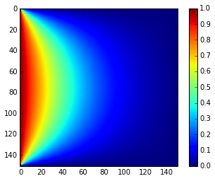

```python
plt.imshow(U)
plt.colorbar()
```

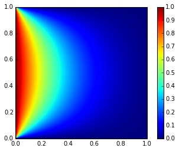

```python
plt.imshow(U, extent=[0,1,0,1],origin='lower')
plt.colorbar()
```

```python
anim = plt.figure(figsize=(6,6))
ax = anim.add_subplot(111)
ax.set_title("2D Poisson Equation",fontsize=14)

plt.xlim([0,1])
plt.ylim([0,1])

def init():
    def BC(x,y):
       if y==0:
          return 1
       else: return 0
    ff= lambda x,y: 0
    U = calc(ff,150,0,num_update)
    return ax.imshow(U, extent=[0,1,0,1])
def animate(i):
    def BC(x,y):
       if y==0:
          return 1
       else: return 0
    ff= lambda x,y: 0
    U = calc(ff,150,500*i,num_update)
    return ax.imshow(U, extent=[0,1,0,1])

animation.FuncAnimation(anim, animate, init_func=init, frames=20, interval=5)
```

[figure not shown]

Once Loop Reflect

## Case 2: $f=0,\phi(x,0)=\sin(2\pi x)$

```python
def BC(x,y):
    if y==0:
       return sin(2*pi*x)
    else: return 0

ff= lambda x,y: 0
```

```python
U = calc(ff,100,10000,num_update)
```

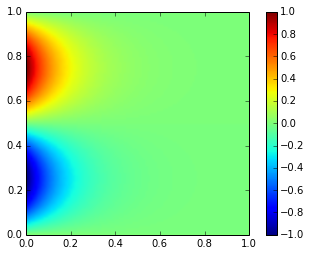

```python
plt.imshow(U, extent=[0,1,0,1])
plt.colorbar()
```

```python
anim = plt.figure(figsize=(6,6))
ax = anim.add_subplot(111)
ax.set_title("2D Poisson Equation",fontsize=14)

plt.xlim([0,1])
plt.ylim([0,1])

def init():
    def BC(x,y):
        if y==0:
           return sin(2*pi*x)
        else: return 0
    ff= lambda x,y: 0
    U = calc(ff,150,0,num_update)
    return ax.imshow(U, extent=[0,1,1,0])
def animate(i):
    def BC(x,y):
        if y==0:
           return sin(2*pi*x)
        else: return 0
    ff= lambda x,y: 0
    U = calc(ff,150,500*i,num_update)
    return ax.imshow(U, extent=[0,1,1,0])

animation.FuncAnimation(anim, animate, init_func=init, frames=20, interval=5)
```

[figure not shown]

Once Loop Reflect

## Case 3: $f=0,u|_{\partial \Omega}=1$

```python
BC= lambda x,y: 1.
ff= lambda x,y: 0
```

```python
U = calc(ff,150,10000,num_update)
```

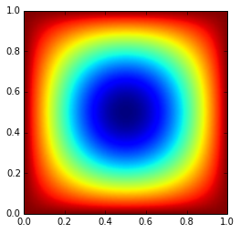

```python
#plt.imshow(U, extent=[0,1,1,0])
plt.imshow(U,origin='lower',extent=[0,1,0,1])
```

## Coulomb’s law

The theorem describes that the force between charged particles with relative positions $r$ has the form $F=\frac{q_1q_2}{4\pi\epsilon_0r^2}\hat r$ $q_1$ and $q_2$ being the charges of the particles and $\epsilon_0$ being the vacuum permittivity.

## Gauss’s law

states that the total electrical flux through a closed surface has to be proportional to the electric charge contained within the surface: $\oint_{A} E \cdot d A= \frac{Q}{\epsilon_{0}} = \frac{1}{\epsilon_{0}} \int_{V} \rho d V$ where $A$ is the surface encapsulating the volume $ V , Q$ is the net charge in this volume and $\rho$ is the charge density.

Defining electric potential $V$ by the relation: $E=-\nabla V$ then $\nabla \cdot E = \nabla\cdot(-\nabla V)= -\nabla^2V= \frac{\rho}{\epsilon_0}$

## Example

$x\times y=[0,1]^2$ and charge $3$ at the center, i.e. $\rho/\epsilon_0=3 /\triangle x^2=3 N^2$ where $N$ is the number of partition.

```python
N=100
BC= lambda x,y:0

def ff(x,y):
    if x==0.5 and y==0.5:
       return -3*N**2
    else:
       return 0
```

```python
U = calc(ff,N,10000,num_update);
```

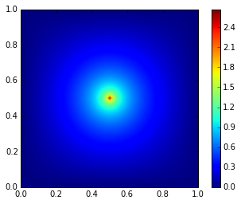

```python
plt.imshow(U, extent=[0,1,0,1])
plt.colorbar()
```

### Case 4: $f=-(6y+4\pi^2(y-y^3))\sin(2\pi x),u|_{\partial \Omega}=0$

Now let's solve the 2D BVP

$\nabla^2 u = -(6y+4\pi^2(y-y^3))\sin(2\pi x)$

on the unit square $[0,1]\times[0,1]$ with homogeneous Dirichlet boundary conditions (i.e., $u(x,y)=0$ everywhere on the boundary). You can do this as follows:

1. Choose a number of grid points $m$.
2. Set up one-dimensional coordinate arrays $x$ and $y$ using np.linspace().
3. Set up boundary condition and flux funxtion, $f(x,y).
4. Solve by numeric scheme.
5. make 2D-picture by imshow().

## Theoratic Solution:

```python
from sympy import symbols,diff,Function,sin,pi,pprint
```

```python
x,y = symbols("x y")
F=Function('F')(x,y)
F=(y-y**3)*sin(2*pi*x)
```

```python
pprint(F.diff(x,2)+F.diff(y,2))
```

```
   2   ⎛ 2    ⎞
4⋅π ⋅y⋅⎝y  - 1⎠⋅sin(2⋅π⋅x) - 6⋅y⋅sin(2⋅π⋅x)
```

```python
def f_(a,b):
    return f.subs({x:a,y:b})
f_(0.5,0.5)
```

```
-0.468750000000000
```

Use this to compute the error in your solution. Try changing $m$. What is the rate of convergence?

```python
BC= lambda x,y: 0

ff=  lambda x,y: -(6*y+4*pi**2*(y-y**3.))*sin(2*pi*x)
#ff=  lambda x,y: np.sin(2*np.pi*x)
```

```python
U = calc(ff,100,10000,num_update)
```

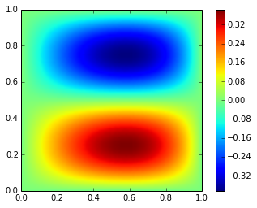

```python
#U=U/(100.**3)
plt.imshow(U,origin='lower', extent=[0,1,0,1])
plt.colorbar()
```

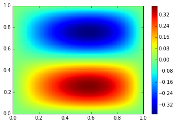

```python
X=np.linspace(0,1,101)
Y=np.linspace(0,1,101)
plt.pcolor(X,Y,U)
#plt.imshow(U,origin='lower', extent=[0,1,0,1])
plt.colorbar()
```

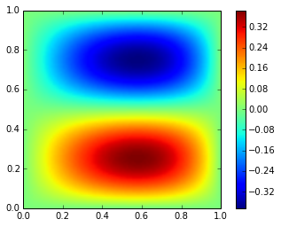

```python
from numpy import pi,sin
Sol= lambda x,y: (y-y**3.)*sin(2*pi*x)
xmesh=np.linspace(0,1,100)
ymesh=np.linspace(0,1,100)
UU = np.zeros([100, 100])
for i in np.arange(100):
    for j in np.arange(100):
        UU[i,j]=Sol(xmesh[i],ymesh[j])
plt.imshow(UU, origin='lower', extent=[0,1,0,1])
plt.colorbar()
```

## Exercise #9:

```python
%%bash
cd DiffE
```

[output not shown]